# DS 202 - lab #4: Joining and Tidying

Dongming Li

10/10/2020

## Part one: Cleaning data

```r
library(readxl)
library(readxl)
library(ggplot2)
library(tidyverse)
library(dplyr)
defense <- read_excel("/Users/dongm/OneDrive/Desktop/ds202_lab4/cyclonesFootball2019.xlsx", sheet='Defensive')
offense <- read_excel("/Users/dongm/OneDrive/Desktop/ds202_lab4/cyclonesFootball2019.xlsx", sheet='Offensive')
biography <- read_excel("/Users/dongm/OneDrive/Desktop/ds202_lab4/cyclonesFootball2019.xlsx", sheet='Biography')

defense2018 <- read_excel("/Users/dongm/OneDrive/Desktop/ds202_lab4/cyclonesFootball2018.xlsx", sheet='Defensive')
offense2018 <- read_excel("/Users/dongm/OneDrive/Desktop/ds202_lab4/cyclonesFootball2018.xlsx", sheet='Offensive')
biography2018 <- read_excel("/Users/dongm/OneDrive/Desktop/ds202_lab4/cyclonesFootball2018.xlsx", sheet='Biography')
```

Although the three Excel sheets are loaded into R, they are not useful before some cleaning. Manipulate the three imported data frames, so that in the cleaned dataset:

1. The player names and opponent names are factors.

```r
defClean <- defense %>%
  mutate_at(c('Name', 'Opponent_Opponent'), factor)

offClean <- offense %>%
  mutate_at(c('Name', 'Opponent_Opponent'), factor)

bioClean <- biography %>%
  mutate_at(c('Name'), factor)

str(defClean)
```

```
## tibble [502 x 11] (S3: tbl_df/tbl/data.frame)
##  $ Name             : Factor w/ 43 levels "Akers, Landen",..: 40 40 40 40 40 40 40 40 40 40 ...
##  $ Opponent_Opponent: Factor w/ 13 levels "Baylor","Iowa",..: 12 2 11 1 8 13 10 7 6 9 ...
##  $ Tackles_Solo     : chr [1:502] "4" "4" "3" "4" ...
##  $ Tackles_ASST     : chr [1:502] "4" "7" "5" "2" ...
##  $ Tackles_TFL      : chr [1:502] "0" "0" "0" "0" ...
##  $ Tackles_Sack     : chr [1:502] "0" "0" "0" "0" ...
##  $ Turnover_FF      : chr [1:502] "0" "0" "0" "0" ...
##  $ Turnover_FR      : chr [1:502] "0" "0" "0" "0" ...
##  $ Turnover_INT     : chr [1:502] "0" "0" "1" "0" ...
##  $ Pass_QBH         : chr [1:502] "1" "0" "0" "0" ...
##  $ Pass_PB          : chr [1:502] "1" "2" "0" "0" ...
```

```r
str(offClean)
```

```
## tibble [195 x 12] (S3: tbl_df/tbl/data.frame)
##  $ Name             : Factor w/ 17 levels "Akers, Landen",..: 1 1 1 1 1 1 1 1 1 1 ...
##  $ Opponent_Opponent: Factor w/ 13 levels "Baylor","Iowa",..: 12 2 11 1 8 13 10 7 6 9 ...
##  $ Rushing_ATT      : chr [1:195] "0" "0" "1" "0" ...
##  $ Rushing_YDS      : chr [1:195] "0" "0" "8" "0" ...
##  $ Rushing_TD       : chr [1:195] "0" "0" "0" "0" ...
##  $ Receiving_REC    : chr [1:195] "1" "0" "0" "0" ...
##  $ Receiving_YDS    : chr [1:195] "21" "0" "0" "0" ...
##  $ Receiving_TD     : chr [1:195] "0" "0" "0" "0" ...
##  $ Passing_CMP-ATT  : chr [1:195] NA NA NA NA ...
##  $ Passing_YDS      : chr [1:195] NA NA NA NA ...
##  $ Passing_TD       : chr [1:195] NA NA NA NA ...
##  $ Passing_INT      : chr [1:195] NA NA NA NA ...
```

```r
str(bioClean)
```

```
## tibble [105 x 7] (S3: tbl_df/tbl/data.frame)
##  $ Name      : Factor w/ 105 levels "Akers, Landen",..: 1 2 3 4 5 6 7 8 9 10 ...
##  $ Position  : chr [1:105] "Wide Receiver" "Tight End" "Wide Receiver" "Placekicker" ...
##  $ Height    : chr [1:105] "6-0" "6-7" "6-5" "6-0" ...
##  $ Weight    : chr [1:105] "188" "245" "204" "195" ...
##  $ Class     : chr [1:105] "Redshirt Senior" "Redshirt Senior" "Redshirt Freshman" "Redshirt Senior" ...
##  $ Hometown  : chr [1:105] "Cedar Rapids, Iowa" "Nixa, Mo." "Seffner, Fla." "Naperville, Ill." ...
##  $ Highschool: chr [1:105] "Washington" "Nixa" "Armwood" "Central" ...
```

2. All offensive and defensive statistics are numerical. The Weight column in biogrpahy is also numeric. (Optional: Learn to mutate multiple columns systematically using the ?across function in `dplyr)

```r
defClean <- defClean %>%
  mutate(across(where(is.character), as.numeric))

offClean <- offClean %>%
  mutate(across(where(is.character), as.numeric))
offClean[is.na(offClean)]=0

bioClean <- bioClean %>%
  mutate(Weight=as.numeric(Weight))

str(defClean)
```

```
## tibble [502 x 11] (S3: tbl_df/tbl/data.frame)
##  $ Name             : Factor w/ 43 levels "Akers, Landen",..: 40 40 40 40 40 40 40 40 40 40 ...
##  $ Opponent_Opponent: Factor w/ 13 levels "Baylor","Iowa",..: 12 2 11 1 8 13 10 7 6 9 ...
##  $ Tackles_Solo     : num [1:502] 4 4 3 4 3 1 7 3 6 5 ...
##  $ Tackles_ASST     : num [1:502] 4 7 5 2 2 1 1 2 1 5 ...
##  $ Tackles_TFL      : num [1:502] 0 0 0 0 1 0 0 0 1 1 ...
##  $ Tackles_Sack     : num [1:502] 0 0 0 0 0 0 0 0 0 1 ...
##  $ Turnover_FF      : num [1:502] 0 0 0 0 0 0 0 0 0 0 ...
##  $ Turnover_FR      : num [1:502] 0 0 0 0 0 0 0 0 0 0 ...
##  $ Turnover_INT     : num [1:502] 0 0 1 0 0 0 0 0 1 0 ...
##  $ Pass_QBH         : num [1:502] 1 0 0 0 0 0 0 0 1 0 ...
##  $ Pass_PB          : num [1:502] 1 2 0 0 0 1 0 0 0 0 ...
```

```r
str(offClean)
```

```
## tibble [195 x 12] (S3: tbl_df/tbl/data.frame)
##  $ Name             : Factor w/ 17 levels "Akers, Landen",..: 1 1 1 1 1 1 1 1 1 1 ...
##  $ Opponent_Opponent: Factor w/ 13 levels "Baylor","Iowa",..: 12 2 11 1 8 13 10 7 6 9 ...
##  $ Rushing_ATT      : num [1:195] 0 0 1 0 0 0 0 0 0 0 ...
##  $ Rushing_YDS      : num [1:195] 0 0 8 0 0 0 0 0 0 0 ...
##  $ Rushing_TD       : num [1:195] 0 0 0 0 0 0 0 0 0 0 ...
##  $ Receiving_REC    : num [1:195] 1 0 0 0 1 0 0 4 0 1 ...
##  $ Receiving_YDS    : num [1:195] 21 0 0 0 32 0 0 39 0 7 ...
##  $ Receiving_TD     : num [1:195] 0 0 0 0 0 0 0 0 0 0 ...
##  $ Passing_CMP-ATT  : num [1:195] 0 0 0 0 0 0 0 0 0 0 ...
##  $ Passing_YDS      : num [1:195] 0 0 0 0 0 0 0 0 0 0 ...
##  $ Passing_TD       : num [1:195] 0 0 0 0 0 0 0 0 0 0 ...
##  $ Passing_INT      : num [1:195] 0 0 0 0 0 0 0 0 0 0 ...
```

```r
str(bioClean)
```

```
## tibble [105 x 7] (S3: tbl_df/tbl/data.frame)
##  $ Name      : Factor w/ 105 levels "Akers, Landen",..: 1 2 3 4 5 6 7 8 9 10 ...
##  $ Position  : chr [1:105] "Wide Receiver" "Tight End" "Wide Receiver" "Placekicker" ...
##  $ Height    : chr [1:105] "6-0" "6-7" "6-5" "6-0" ...
##  $ Weight    : num [1:105] 188 245 204 195 190 235 255 285 300 215 ...
##  $ Class     : chr [1:105] "Redshirt Senior" "Redshirt Senior" "Redshirt Freshman" "Redshirt Senior" ...
##  $ Hometown  : chr [1:105] "Cedar Rapids, Iowa" "Nixa, Mo." "Seffner, Fla." "Naperville, Ill." ...
##  $ Highschool: chr [1:105] "Washington" "Nixa" "Armwood" "Central" ...
```

3. Change the Height column in biogrpahy into numeric. (Hint: Use a unit that works well)

```r
bioClean <- bioClean %>%
  separate(Height, c("foot","inch"), sep="-") %>%
  mutate(foot=as.numeric(foot)) %>%
  mutate(inch=as.numeric(inch))
str(bioClean)
```

```
## tibble [105 x 8] (S3: tbl_df/tbl/data.frame)
##  $ Name      : Factor w/ 105 levels "Akers, Landen",..: 1 2 3 4 5 6 7 8 9 10 ...
##  $ Position  : chr [1:105] "Wide Receiver" "Tight End" "Wide Receiver" "Placekicker" ...
##  $ foot      : num [1:105] 6 6 6 6 6 6 6 6 6 6 ...
##  $ inch      : num [1:105] 0 7 5 0 0 3 2 2 0 6 ...
##  $ Weight    : num [1:105] 188 245 204 195 190 235 255 285 300 215 ...
##  $ Class     : chr [1:105] "Redshirt Senior" "Redshirt Senior" "Redshirt Freshman" "Redshirt Senior" ...
##  $ Hometown  : chr [1:105] "Cedar Rapids, Iowa" "Nixa, Mo." "Seffner, Fla." "Naperville, Ill." ...
##  $ Highschool: chr [1:105] "Washington" "Nixa" "Armwood" "Central" ...
```

## Part two: Tidying

For the following questions, work on the cleaned data frames defClean, offClean, and bioClean.

1. Reformat the defClean data frame into a tidy format using pivot_longer. The type of statistic (Tackles_Solo, Tackles_ASST, etc) is added as a new key column named stat.

```r
defClean <- defClean %>%
  pivot_longer(cols=Tackles_Solo:Pass_PB, names_to='stat')

str(defClean)
```

```
## tibble [4,518 x 4] (S3: tbl_df/tbl/data.frame)
##  $ Name             : Factor w/ 43 levels "Akers, Landen",..: 40 40 40 40 40 40 40 40 40 40 ...
##  $ Opponent_Opponent: Factor w/ 13 levels "Baylor","Iowa",..: 12 12 12 12 12 12 12 12 12 2 ...
##  $ stat             : chr [1:4518] "Tackles_Solo" "Tackles_ASST" "Tackles_TFL" "Tackles_Sack" ...
##  $ value            : num [1:4518] 4 4 0 0 0 0 0 1 1 4 ...
```

2. Compare the distributions of the defensive statistics. What defensive skills are rare?

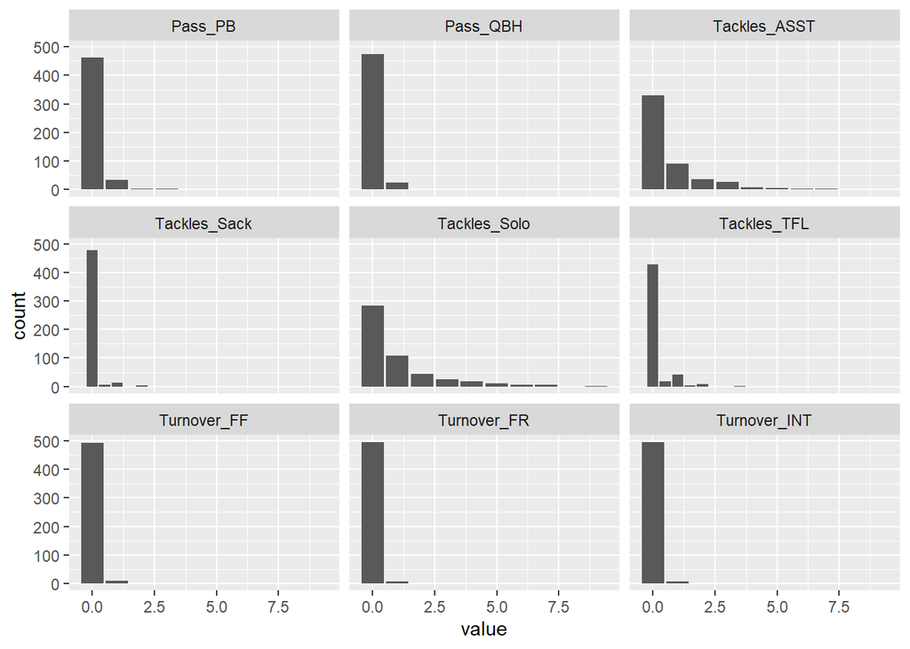

```
I think Pass_PB, Pass_QBH, Tackles_Sack, Turnover_FF, Turnover_FR, and Turnover_INT are rare defensive skills because the number of people who have a good value for these skills are few.
```

```r
ggplot(defClean,aes(x=value)) + geom_bar() + facet_wrap(~stat)
```

3. Did ISU have better defense against Iowa or Notre Dame? Answer this question by creating a scatterplot with x- and y-axes being the number of solo tackles (of each player). A large number of solo tackles is an indicator of good defense.

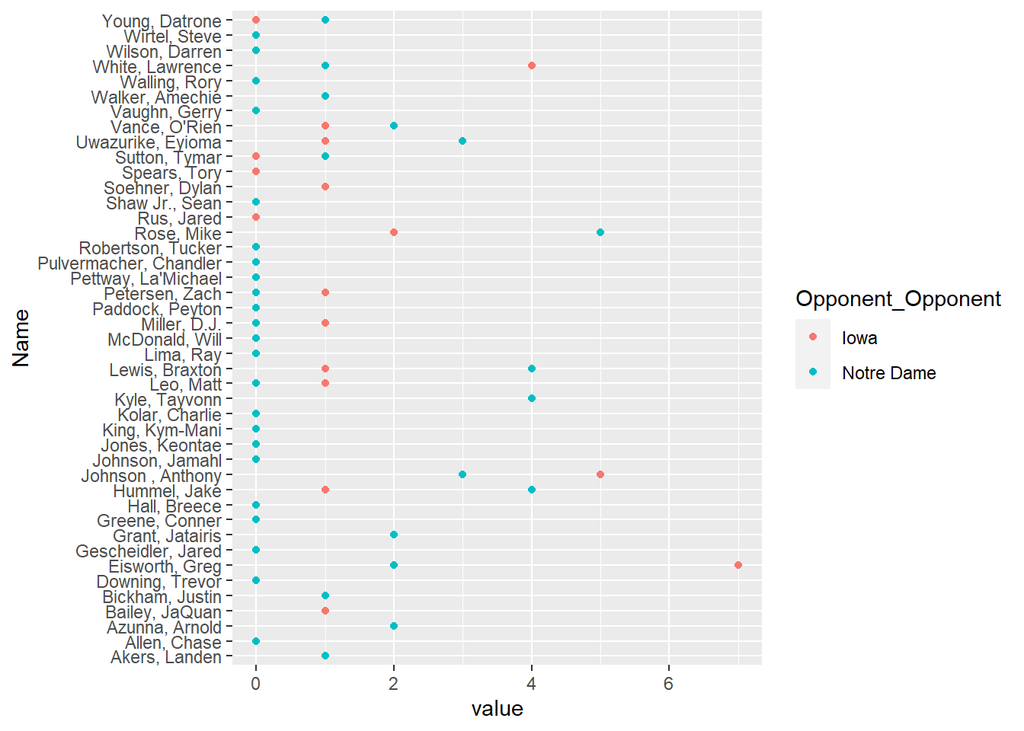

```
In general, ISU have better defense against Notre Dame because more players have more solo tackles against Notre Dame than against Iowa.
```

```r
defClean1<-defClean %>%
  filter(Opponent_Opponent %in% c('Iowa', 'Notre Dame'), stat=='Tackles_Solo')

ggplot(defClean1,aes(x=value,y=Name,color=Opponent_Opponent)) + geom_point()
```

Now turn our attention to the player biography.

4. Separate the Hometown column into two columns, namely the city and the state. Print the first few rows of these two columns. (Hint: look at the sep= argument of separate)

```r
bioClean <- bioClean %>%
  separate(Hometown, c("city","state"), sep=",")
head(bioClean)
```

```
## # A tibble: 6 x 9
##   Name       Position     foot  inch Weight Class     city     state  Highschool
##   <fct>      <chr>       <dbl> <dbl>  <dbl> <chr>     <chr>    <chr>  <chr>
## 1 Akers, La~ Wide Recei~     6     0    188 Redshirt~ Cedar R~ " Iow~ Washington
## 2 Allen, Ch~ Tight End       6     7    245 Redshirt~ Nixa     " Mo." Nixa
## 3 Anderson,~ Wide Recei~     6     5    204 Redshirt~ Seffner  " Fla~ Armwood
## 4 Assalley,~ Placekicker     6     0    195 Redshirt~ Napervi~ " Ill~ Central
## 5 Azunna, A~ Defensive ~     6     0    190 Redshirt~ Grand P~ " Tex~ Lake Ridge
## 6 Bailey, C~ Defensive ~     6     3    235 Redshirt~ Clarksd~ " Mis~ Clarksdale
```

5. How many players are there from each state?

```r
bioClean %>%
  group_by(state) %>%
  summarise(StateSUM=n()) %>%
  arrange(StateSUM)
```

```
## # A tibble: 19 x 2
##    state        StateSUM
##    <chr>           <int>
##  1 " Ark."             1
##  2 " Australia"        1
##  3 " Miss."            1
##  4 " Pa."              1
##  5 " Okla."            2
##  6 " S.D."             2
##  7 " Calif."           3
##  8 " Kan."             3
##  9 " Ariz."            4
## 10 " Ga."              4
## 11 " Mich."            4
## 12 " Minn."            4
## 13 " Ill."             5
## 14 " Mo."              6
## 15 " Texas"            6
## 16 " Wis."             6
## 17 " Ohio"             7
## 18 " Fla."            10
## 19 " Iowa"            35
```

## Part three: Joining data frames

1. Find which states do the ISU defensive and offensive players come from. Create an appropriate summary.

```r
offClean %>%
  select(Name) %>%
  distinct() %>%
  left_join(bioClean, by=c("Name"))%>%
  group_by(state) %>%
  drop_na() %>%
  summarise(StateSUM=n()) %>%
  arrange(StateSUM)
```

```
## # A tibble: 11 x 2
##    state    StateSUM
##    <chr>       <int>
##  1 " Ariz."        1
##  2 " Ark."         1
##  3 " Ga."          1
##  4 " Ill."         1
##  5 " Iowa"         1
##  6 " Kan."         1
##  7 " Mo."          1
##  8 " Ohio"         1
##  9 " Texas"        1
## 10 " Fla."         2
## 11 " Okla."        2
```

```r
defClean %>%
  select(Name) %>%
  distinct() %>%
  left_join(bioClean, by=c("Name"))%>%
  group_by(state) %>%
  drop_na() %>%
  summarise(StateSUM=n()) %>%
  arrange(StateSUM)
```

```
## # A tibble: 12 x 2
##    state     StateSUM
##    <chr>        <int>
##  1 " Ark."          1
##  2 " Kan."          1
##  3 " Mich."         1
##  4 " Calif."        2
##  5 " Mo."           2
##  6 " Okla."         2
##  7 " Texas"         2
##  8 " Wis."          2
##  9 " Ga."           3
## 10 " Ohio"          3
## 11 " Fla."          4
## 12 " Iowa"          7
```

2. How does the performance of quarterback Brock Purdy relate to the performance of the ISU team?

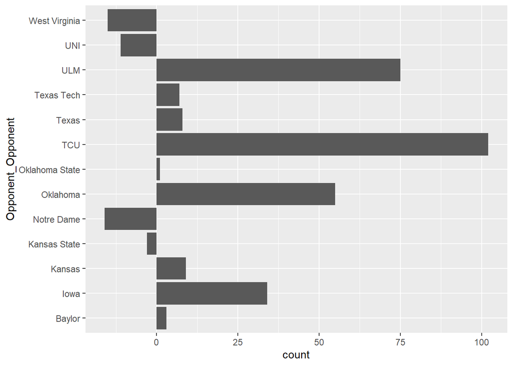

```r
BROCK <- offClean[offClean$Name=='Purdy, Brock',]

BROCK1 <- BROCK %>%
  select(c(Opponent_Opponent, Rushing_YDS))

ggplot(BROCK1,aes(y=Opponent_Opponent,weight=Rushing_YDS)) + geom_bar()
```

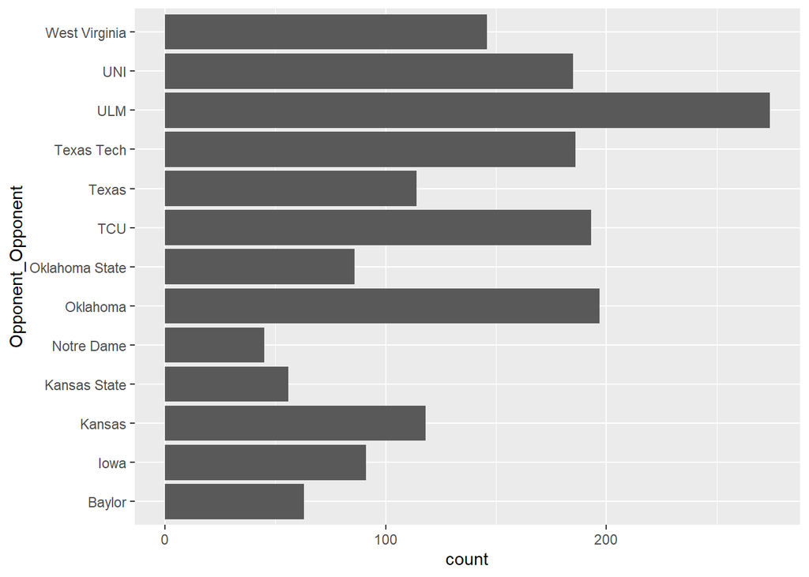

[output not shown]

```r
offClean %>%
  select(Opponent_Opponent, Rushing_YDS)%>%
  group_by(Opponent_Opponent) %>%
  drop_na() %>%
  ggplot(aes(y=Opponent_Opponent,weight=Rushing_YDS)) + geom_bar()
```

3. Which ISU player(s) made big progress over the last year? Compare the 2019 and the 2018 data here.

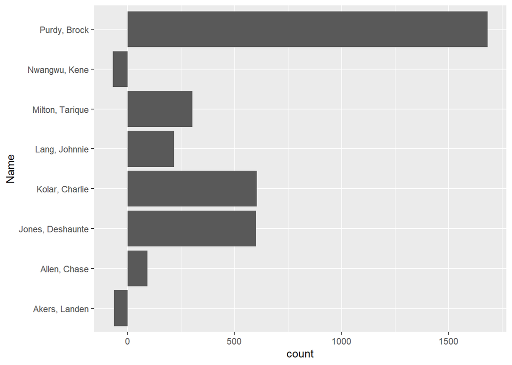

```r
defClean2018 <- defense2018 %>%
  mutate_at(c('Name', 'Opponent_Opponent'), factor)%>%
  mutate(across(where(is.character), as.numeric))%>%
  pivot_longer(Tackles_Solo:Pass_PB, names_to='stat')

offClean2018 <- offense2018 %>%
  mutate_at(c('Name', 'Opponent_Opponent'), factor)%>%
  mutate(across(where(is.character), as.numeric))
offClean2018[is.na(offClean2018)]=0

offpoint2018 <- offClean2018 %>%
  mutate(sum = Receiving_REC    + Receiving_YDS + Receiving_TD + Rushing_ATT + Rushing_YDS + Rushing_TD + `Passing_CMP-ATT` + Passing_YDS+ Passing_TD+Passing_INT) %>%
  select(Name, sum) %>%
  group_by(Name) %>%
  drop_na() %>%
  summarise(point2018=sum(sum))

offpoint2019 <- offClean %>%
  mutate(sum = Receiving_REC    + Receiving_YDS + Receiving_TD + Rushing_ATT + Rushing_YDS + Rushing_TD + `Passing_CMP-ATT` + Passing_YDS+ Passing_TD+Passing_INT) %>%
  select(Name, sum) %>%
  group_by(Name) %>%
  drop_na() %>%
  summarise(point2019=sum(sum))

dat1<-inner_join(offpoint2018,offpoint2019,by='Name')%>%
  mutate(Increase= point2019 - point2018)

ggplot(dat1,aes(y=Name,weight=Increase)) + geom_bar()
```

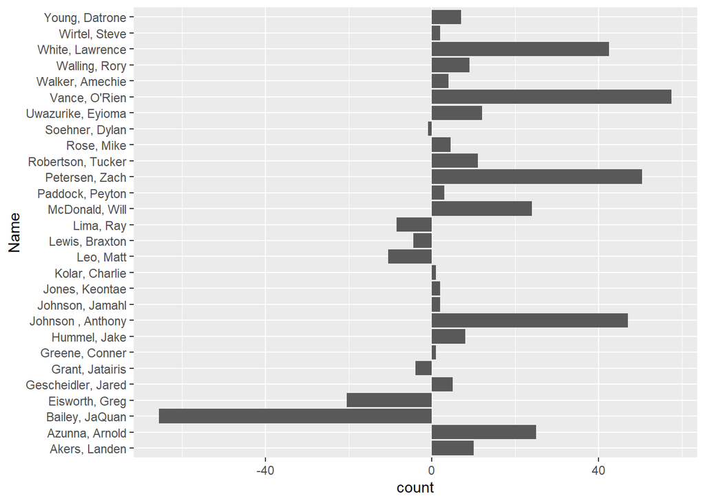

[output not shown]

```r
def2018<-defClean2018 %>%
  select(Name,value)%>%
  group_by(Name)%>%
  drop_na()%>%
  summarise(point2018=sum(value))

def2019<-defClean %>%
  select(Name,value)%>%
  mutate(value=as.numeric(value))%>%
  group_by(Name)%>%
  drop_na()%>%
  summarise(point2019=sum(value))

dat4<-inner_join(def2018,def2019,by='Name') %>%
  mutate(Increase= point2019 - point2018)

ggplot(dat4,aes(y=Name,weight=Increase)) + geom_bar()
```